# BIS15L_AI_hmwk

Ryan Chiang

2024-03-07

## Instructions

This homework is a bit less traditional this week. There are some errors in the code below. In addition add notes and titles to the code chunks that explains what the code chunck does. Use AI tools, notes from class, or any other resources to help fix the errors. Feel free to edit any plots to your preference. Don’t forget to answer the two questions at the bottom. Upon completion, you should not have to ‘#’ out any of the code chunks.

Push your final work to your repository. Your final lab report should be organized, clean, and run free from errors. Remember, you must remove the `#` for the included code chunks to run. Be sure to add your name to the author header above.

Again make sure to use the formatting conventions of RMarkdown to make your report neat and clean!

```r
library(tidyverse)
library(janitor)
library(dplyr)
```

```r
blood_count <- read_csv("../lab15/data/blood_count_dataset.csv") %>% clean_names()
glimpse(blood_count)
```

```
## Rows: 417
## Columns: 9
## $ age               <dbl> 68, 25, 57, 28, 38, 47, 37, 30, 35, 22, 41, 34, 40, …
## $ gender            <chr> "Female", "Male", "Male", "Female", "Male", "Female"…
## $ hemoglobin        <dbl> 10.4, 13.8, 13.5, 12.7, 14.9, 12.0, 14.5, 11.8, 11.5…
## $ platelet_count    <dbl> 180000, 320000, 370000, 290000, 380000, 260000, 3800…
## $ white_blood_cells <dbl> 5700, 7500, 8500, 7800, 8700, 7000, 8700, 7000, 7100…
## $ red_blood_cells   <dbl> 3.7, 5.4, 5.1, 4.8, 5.7, 4.4, 5.7, 4.2, 4.2, 5.6, 4.…
## $ mcv               <dbl> 77, 92, 90, 86, 95, 87, 95, 84, 84, 93, 88, 85, 96, …
## $ mch               <dbl> 25, 30, 29, 29, 31, 28, 31, 27, 27, 31, 29, 28, 32, …
## $ mchc              <dbl> 32, 32, 32, 33, 33, 32, 33, 32, 32, 32, 33, 32, 33, …
```

### misspelled glimpse

```r
blood_count %>%
  group_by(gender) %>%
  summarize(
    min = min(red_blood_cells),
    mean = mean(red_blood_cells),  # Corrected 'maen' to 'mean'
    max = max(red_blood_cells))  # Removed the extra '-' before 'whats'
```

```
## # A tibble: 2 × 4
##   gender   min  mean   max
##   <chr>  <dbl> <dbl> <dbl>
## 1 Female   3.6  4.36   4.9
## 2 Male     5    5.38   5.8
```

```r
options(scipen = 999, digits = 2)

blood_count %>%
  filter(gender == "male") %>%  # Changed "Gender" to "gender" and added "=="
  select(3:9) %>%  # Changed square brackets to parentheses for select function
  colMeans(na.rm = TRUE)  # Added parentheses for colMeans function
```

```
##        hemoglobin    platelet_count white_blood_cells   red_blood_cells
##               NaN               NaN               NaN               NaN
##               mcv               mch              mchc
##               NaN               NaN               NaN
```

```r
blood_count %>%
  filter(gender == "Female") %>%  # Changed "Gender" to "gender" and added "=="
  select(3:9) %>%  # Changed square brackets to parentheses for select function
  colMeans(na.rm = TRUE)  # Changed 'T' to 'TRUE' for na.rm parameter
```

```
##        hemoglobin    platelet_count white_blood_cells   red_blood_cells
##              11.9          255913.5            6967.8               4.4
##               mcv               mch              mchc
##              84.9              27.7              32.2
```

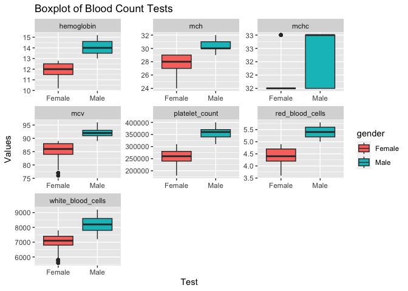

```r
blood_count %>%
  pivot_longer(cols = 3:9, names_to = "Test", values_to = "Values") %>%
  ggplot(aes(x = gender, y = Values, fill = gender)) +
  geom_boxplot() +
  facet_wrap(~ Test, scales = "free") +
  labs(title = "Boxplot of Blood Count Tests",
       x = "Test",
       y = "Values")
```

```r
library(dplyr)

grouped_bc <- blood_count %>%
  mutate(Age_Group = case_when(
    age >= 20 & age <= 29 ~ "20s",
    age >= 30 & age <= 39 ~ "30s",
    age >= 40 & age <= 49 ~ "40s",
    age >= 50 & age <= 59 ~ "50s",
    age >= 60 ~ "60s")) # Combining all ages 60 and above into "60s"

head(grouped_bc)
```

```
## # A tibble: 6 × 10
##     age gender hemoglobin platelet_count white_blood_cells red_blood_cells   mcv
##   <dbl> <chr>       <dbl>          <dbl>             <dbl>           <dbl> <dbl>
## 1    68 Female       10.4         180000              5700             3.7    77
## 2    25 Male         13.8         320000              7500             5.4    92
## 3    57 Male         13.5         370000              8500             5.1    90
## 4    28 Female       12.7         290000              7800             4.8    86
## 5    38 Male         14.9         380000              8700             5.7    95
## 6    47 Female       12           260000              7000             4.4    87
## # ℹ 3 more variables: mch <dbl>, mchc <dbl>, Age_Group <chr>
```

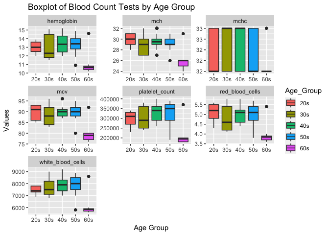

```r
blood_count <- blood_count %>%
  mutate(Age_Group = case_when(
    age >= 20 & age <= 29 ~ "20s",
    age >= 30 & age <= 39 ~ "30s",
    age >= 40 & age <= 49 ~ "40s",
    age >= 50 & age <= 59 ~ "50s",
    age >= 60 ~ "60s")) # Combining all ages 60 and above into "60s"

# Plotting code
blood_count %>%
  pivot_longer(cols = 3:9, names_to = "Test", values_to = "Values") %>%
  ggplot(aes(x = Age_Group, y = Values, fill = Age_Group)) +
  geom_boxplot() +
  facet_wrap(~ Test, scales = "free") +
  labs(title = "Boxplot of Blood Count Tests by Age Group",
       x = "Age Group",
       y = "Values")
```

9. What are two drawbacks and two benefits of AI? ## two drawbacks is that you need to be very specific in how you ask it to do something and that it can be a hutch that you get used to and forget how to code 10. Do you think you will use AI for coding in the future? Why or why not? #I will use AI to code because I think it will make my data analysis faster.

## Push your final code to GitHub!

Please be sure that you check the `keep md` file in the knit preferences.